# **Airbnb Booking in New York (2019)**

### **Understanding The Dataset Variables:**

**id :** This is a unique identifier for each listing in the dataset.

**name :** This is the name or title of the listing, as it appears on the Airbnb website.

**Host_id :** This is a unique identifier for each host in the dataset.

**Host_name :** This is the name of the host as it appears on the Airbnb website.

**Neighbourhood_group :** This is a grouping of neighborhoods in New York City, such as Manhattan or Brooklyn.

**Neighbourhood :** This is the specific neighborhood in which the listing is located.

**Latitude :** This is the geographic latitude of the listing.

**Longitude :** This is the geographic longitude of the listing.

**Room_type :** This is the type of room or property being offered, such as an entire home, private room, shared room.

**Price :** This is the nightly price for the listing, in US dollars.

**Minimum_nights :** This is the minimum number of nights that a guest must stay at the listing.

**number_of_reviews :** This is the total number of reviews that the listing has received.

**Reviews_per_month :** This is the average number of reviews that the listing receives per month.

**Host_listings_count :** This is the total number of listings that the host has on Airbnb.

**Availability_365 :** This is the number of days in the next 365 days that the listing is available for booking.

### **Importing Needed Libraries**

```python
import numpy as np
import pandas as pd
import matplotlib.pyplot as plt
%matplotlib inline
import seaborn as sns

import warnings
warnings.filterwarnings('ignore')
```

### Load Dataset

```python
df = pd.read_csv("Airbnb NYC 2019.csv")
df.head()
```

|  | id | name | host_id | host_name | neighbourhood_group | neighbourhood | latitude | longitude | room_type | price | minimum_nights | number_of_reviews | last_review | reviews_per_month | calculated_host_listings_count | availability_365 |
| --- | --- | --- | --- | --- | --- | --- | --- | --- | --- | --- | --- | --- | --- | --- | --- | --- |
| 0 | 2539 | Clean & quiet apt home by the park | 2787 | John | Brooklyn | Kensington | 40.64749 | -73.97237 | Private room | 149 | 1 | 9 | 2018-10-19 | 0.21 | 6 | 365 |
| 1 | 2595 | Skylit Midtown Castle | 2845 | Jennifer | Manhattan | Midtown | 40.75362 | -73.98377 | Entire home/apt | 225 | 1 | 45 | 2019-05-21 | 0.38 | 2 | 355 |
| 2 | 3647 | THE VILLAGE OF HARLEM....NEW YORK ! | 4632 | Elisabeth | Manhattan | Harlem | 40.80902 | -73.94190 | Private room | 150 | 3 | 0 | NaN | NaN | 1 | 365 |
| 3 | 3831 | Cozy Entire Floor of Brownstone | 4869 | LisaRoxanne | Brooklyn | Clinton Hill | 40.68514 | -73.95976 | Entire home/apt | 89 | 1 | 270 | 2019-07-05 | 4.64 | 1 | 194 |
| 4 | 5022 | Entire Apt: Spacious Studio/Loft by central park | 7192 | Laura | Manhattan | East Harlem | 40.79851 | -73.94399 | Entire home/apt | 80 | 10 | 9 | 2018-11-19 | 0.10 | 1 | 0 |

### **Data cleaning and Exploration**

```python
df.shape
```

```
(48895, 16)
```

```python
df.info()
```

```
<class 'pandas.core.frame.DataFrame'>
RangeIndex: 48895 entries, 0 to 48894
Data columns (total 16 columns):
 #   Column                          Non-Null Count  Dtype
---  ------                          --------------  -----
 0   id                              48895 non-null  int64
 1   name                            48879 non-null  object
 2   host_id                         48895 non-null  int64
 3   host_name                       48874 non-null  object
 4   neighbourhood_group             48895 non-null  object
 5   neighbourhood                   48895 non-null  object
 6   latitude                        48895 non-null  float64
 7   longitude                       48895 non-null  float64
 8   room_type                       48895 non-null  object
 9   price                           48895 non-null  int64
 10  minimum_nights                  48895 non-null  int64
 11  number_of_reviews               48895 non-null  int64
 12  last_review                     38843 non-null  object
 13  reviews_per_month               38843 non-null  float64
 14  calculated_host_listings_count  48895 non-null  int64
 15  availability_365                48895 non-null  int64
dtypes: float64(3), int64(7), object(6)
memory usage: 6.0+ MB
```

```python
#Convert from String to date
df['last_review']=df['last_review'].astype('datetime64[ns]')
df['last_review'] = [time.date() for time in df['last_review']]
df['last_review']
```

```
0        2018-10-19
1        2019-05-21
2               NaT
3        2019-07-05
4        2018-11-19
            ...
48890           NaT
48891           NaT
48892           NaT
48893           NaT
48894           NaT
Name: last_review, Length: 48895, dtype: object
```

```python
# fill the nulls
df['name'].fillna('null',inplace= True)
df['host_name'].fillna('null',inplace= True)
df['last_review'].fillna('null',inplace= True)
df['reviews_per_month'].fillna(pd.NA,inplace= True)
```

```python
df.nunique()
```

```
id                                48895
name                              47906
host_id                           37457
host_name                         11453
neighbourhood_group                   5
neighbourhood                       221
latitude                          19048
longitude                         14718
room_type                             3
price                               674
minimum_nights                      109
number_of_reviews                   394
last_review                        1765
reviews_per_month                   937
calculated_host_listings_count       47
availability_365                    366
dtype: int64
```

```python
df.dtypes
```

```
id                                  int64
name                               object
host_id                             int64
host_name                          object
neighbourhood_group                object
neighbourhood                      object
latitude                          float64
longitude                         float64
room_type                          object
price                               int64
minimum_nights                      int64
number_of_reviews                   int64
last_review                        object
reviews_per_month                 float64
calculated_host_listings_count      int64
availability_365                    int64
dtype: object
```

```python
# Check for the duplicates rows
print('number of duplicates: ', df.duplicated().sum())
df[df.duplicated()]
```

```
number of duplicates:  0
```

|  | id | name | host_id | host_name | neighbourhood_group | neighbourhood | latitude | longitude | room_type | price | minimum_nights | number_of_reviews | last_review | reviews_per_month | calculated_host_listings_count | availability_365 |
| --- | --- | --- | --- | --- | --- | --- | --- | --- | --- | --- | --- | --- | --- | --- | --- | --- |

```python
df.describe().T
```

|  | count | mean | std | min | 25% | 50% | 75% | max |
| --- | --- | --- | --- | --- | --- | --- | --- | --- |
| id | 48895.0 | 1.901714e+07 | 1.098311e+07 | 2539.00000 | 9.471945e+06 | 1.967728e+07 | 2.915218e+07 | 3.648724e+07 |
| host_id | 48895.0 | 6.762001e+07 | 7.861097e+07 | 2438.00000 | 7.822033e+06 | 3.079382e+07 | 1.074344e+08 | 2.743213e+08 |
| latitude | 48895.0 | 4.072895e+01 | 5.453008e-02 | 40.49979 | 4.069010e+01 | 4.072307e+01 | 4.076311e+01 | 4.091306e+01 |
| longitude | 48895.0 | -7.395217e+01 | 4.615674e-02 | -74.24442 | -7.398307e+01 | -7.395568e+01 | -7.393627e+01 | -7.371299e+01 |
| price | 48895.0 | 1.527207e+02 | 2.401542e+02 | 0.00000 | 6.900000e+01 | 1.060000e+02 | 1.750000e+02 | 1.000000e+04 |
| minimum_nights | 48895.0 | 7.029962e+00 | 2.051055e+01 | 1.00000 | 1.000000e+00 | 3.000000e+00 | 5.000000e+00 | 1.250000e+03 |
| number_of_reviews | 48895.0 | 2.327447e+01 | 4.455058e+01 | 0.00000 | 1.000000e+00 | 5.000000e+00 | 2.400000e+01 | 6.290000e+02 |
| reviews_per_month | 38843.0 | 1.373221e+00 | 1.680442e+00 | 0.01000 | 1.900000e-01 | 7.200000e-01 | 2.020000e+00 | 5.850000e+01 |
| calculated_host_listings_count | 48895.0 | 7.143982e+00 | 3.295252e+01 | 1.00000 | 1.000000e+00 | 1.000000e+00 | 2.000000e+00 | 3.270000e+02 |
| availability_365 | 48895.0 | 1.127813e+02 | 1.316223e+02 | 0.00000 | 0.000000e+00 | 4.500000e+01 | 2.270000e+02 | 3.650000e+02 |

```python
df.describe(include = 'object').T
```

|  | count | unique | top | freq |
| --- | --- | --- | --- | --- |
| name | 48895 | 47906 | Hillside Hotel | 18 |
| host_name | 48895 | 11453 | Michael | 417 |
| neighbourhood_group | 48895 | 5 | Manhattan | 21661 |
| neighbourhood | 48895 | 221 | Williamsburg | 3920 |
| room_type | 48895 | 3 | Entire home/apt | 25409 |
| last_review | 48895 | 1765 | null | 10052 |

```python
df.columns
```

```
Index(['id', 'name', 'host_id', 'host_name', 'neighbourhood_group',
       'neighbourhood', 'latitude', 'longitude', 'room_type', 'price',
       'minimum_nights', 'number_of_reviews', 'last_review',
       'reviews_per_month', 'calculated_host_listings_count',
       'availability_365'],
      dtype='object')
```

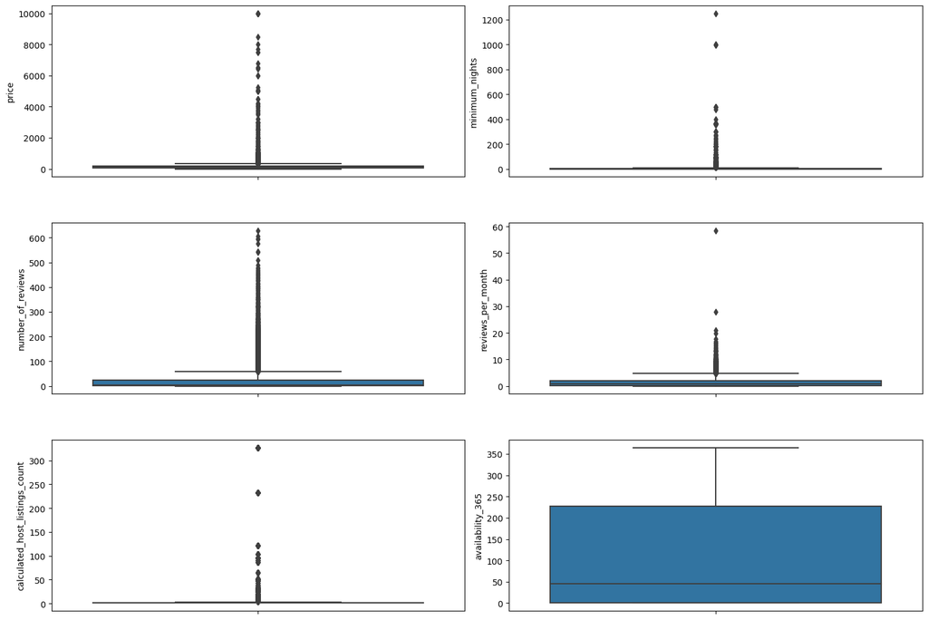

```python
# Check for the outliers by using box plot

fig , axs = plt.subplots(ncols=2 , nrows=3 , figsize=(15,10))
index=0
axs=axs.flatten()
data =df[['price','minimum_nights','number_of_reviews','reviews_per_month','calculated_host_listings_count','availability_365']]
for k,v in data.items():
    sns.boxplot(y=k, data=df , ax=axs[index])
    index+=1
plt.tight_layout(pad=0.4 , w_pad=0.5, h_pad=5)
```

```python
# Number of outliers per columns
for k, v in data.items():
    q1 = v.quantile(0.25)
    q3 = v.quantile(0.75)
    irq = q3 - q1
    v_col = v[(v <= q1 - 1.5 * irq) | (v >= q3 + 1.5 * irq)]
    perc = np.shape(v_col)[0] * 100.0 / np.shape(data)[0]
    print("Column %s outliers = %.2f%%" % (k, perc))
```

```
Column price outliers = 6.09%
Column minimum_nights outliers = 13.58%
Column number_of_reviews outliers = 12.31%
Column reviews_per_month outliers = 3.67%
Column calculated_host_listings_count outliers = 14.48%
Column availability_365 outliers = 0.00%
```

```python
# Remove the outlier of price column within 95% percentile

q_low = df["price"].quantile(0)
q_hi  = df["price"].quantile(0.95)

df = df[(df["price"] < q_hi) & (df["price"] > q_low)]
df.shape
```

```
(46433, 16)
```

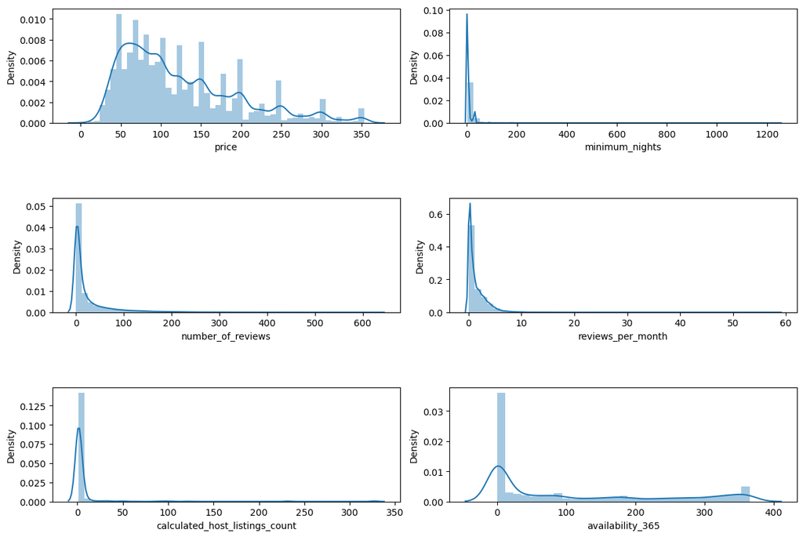

```python
# The distribution of the Data

fig , axs = plt.subplots(ncols=2 , nrows=3 , figsize=(12,8))
index=0
axs=axs.flatten()
data =df[['price','minimum_nights','number_of_reviews','reviews_per_month','calculated_host_listings_count','availability_365']]
for k,v in data.items():
    sns.distplot(v , ax=axs[index])
    index+=1
plt.tight_layout(pad=0.4 , w_pad=0.5, h_pad=5)
```

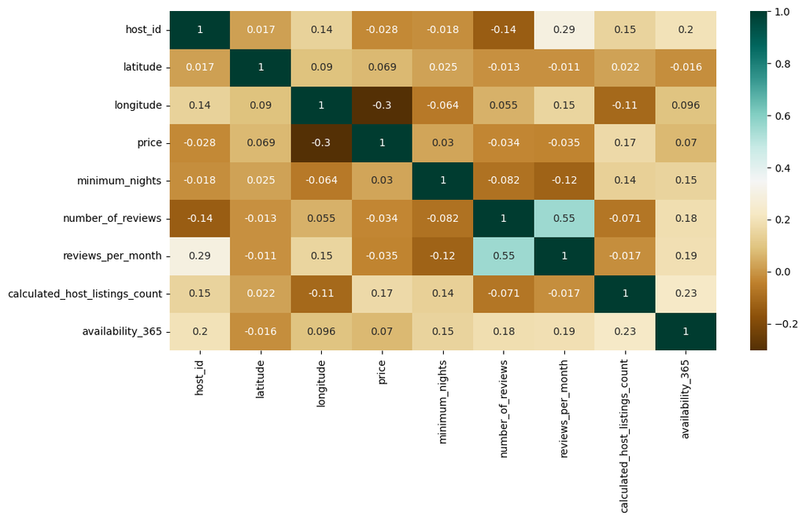

```python
# Correlation Heatmap

data =df[['host_id','latitude','longitude','price','minimum_nights','number_of_reviews',
          'reviews_per_month','calculated_host_listings_count','availability_365']]
corr = data.corr()
plt.figure(figsize=(12,6))

sns.heatmap(corr, cmap='BrBG',annot=True)

plt.show()
```

### **Exploratory Data Analysis**

#### **Total price for each neighbourhood group**

```python
Result=df.groupby(['neighbourhood_group'])['price'].sum()
Result.reset_index()
```

|  | neighbourhood_group | price |
| --- | --- | --- |
| 0 | Bronx | 83831 |
| 1 | Brooklyn | 2102762 |
| 2 | Manhattan | 2970234 |
| 3 | Queens | 501558 |
| 4 | Staten Island | 32571 |

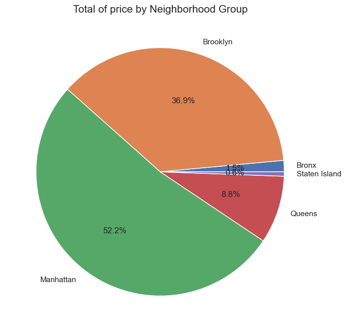

```python
Price_by_neighbourhood_group = df.groupby("neighbourhood_group")["price"].sum()


plt.pie(Price_by_neighbourhood_group, labels=Price_by_neighbourhood_group.index, autopct='%1.1f%%')
plt.title("Total of price by Neighborhood Group", fontsize='15')


plt.show()
```

#### **Average price for neighbourhood group**

```python
df.groupby(['neighbourhood_group'])['price'].mean().reset_index()
```

|  | neighbourhood_group | price |
| --- | --- | --- |
| 0 | Bronx | 78.200560 |
| 1 | Brooklyn | 107.552657 |
| 2 | Manhattan | 149.566141 |
| 3 | Queens | 89.788400 |
| 4 | Staten Island | 89.235616 |

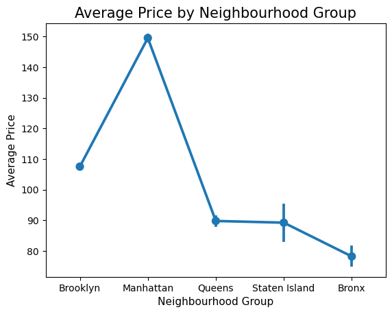

```python
sns.pointplot(x = 'neighbourhood_group', y='price', data=df, estimator = np.mean)

plt.xlabel('Neighbourhood Group',fontsize=11)
plt.ylabel('Average Price',fontsize=11)
plt.title('Average Price by Neighbourhood Group',fontsize=15)
```

#### **Price Distribution for Each Neighborhood Group**

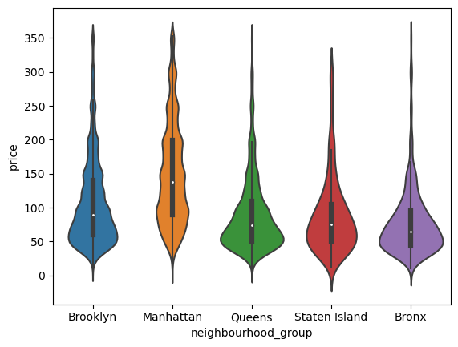

```python
ax= sns.violinplot(x='neighbourhood_group',y='price',data= df)
```

#### **Number of Listings for each neighbourhood group**

```python
Result=df.groupby(['neighbourhood_group'])['calculated_host_listings_count'].count()
Result.reset_index()
```

|  | neighbourhood_group | calculated_host_listings_count |
| --- | --- | --- |
| 0 | Bronx | 1072 |
| 1 | Brooklyn | 19551 |
| 2 | Manhattan | 19859 |
| 3 | Queens | 5586 |
| 4 | Staten Island | 365 |

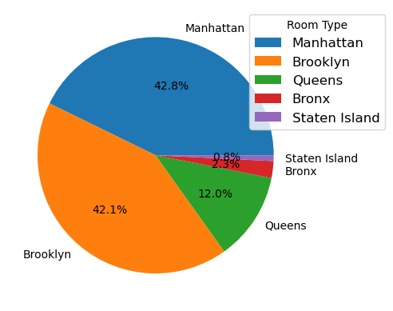

```python
room_type_counts = df['neighbourhood_group'].value_counts()
labels = room_type_counts.index
sizes = room_type_counts.values


plt.pie(sizes, labels=labels, autopct='%1.1f%%')

plt.legend(title='Room Type', bbox_to_anchor=(0.8, 0, 0.5, 1), fontsize='12')

plt.show()
```

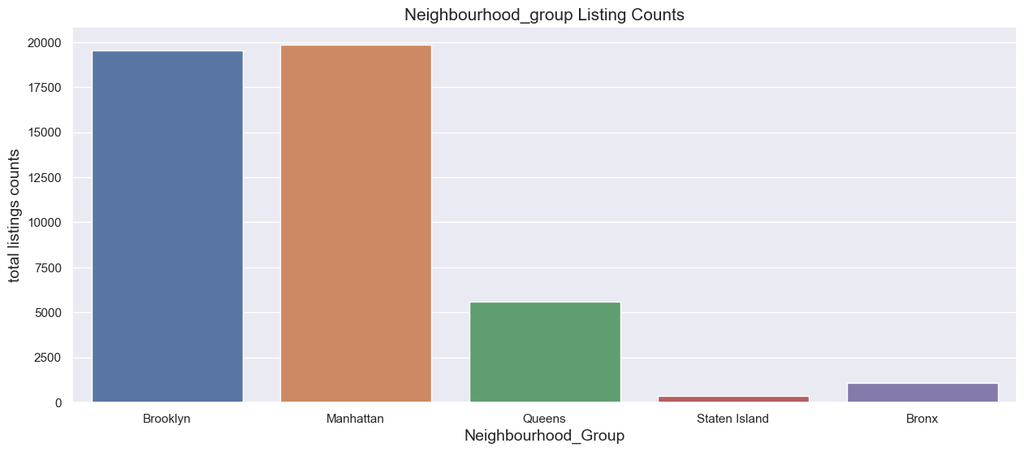

```python
plt.figure(figsize=(15,6))
sns.countplot(df,x='neighbourhood_group')
plt.title('Neighbourhood_group Listing Counts',fontsize=15)
plt.xlabel('Neighbourhood_Group', fontsize=14)
plt.ylabel('total listings counts', fontsize=14)
```

#### **Number of Listings for Top 10 neighbourhoods**

```python
df['neighbourhood'].value_counts()[:10].reset_index()
```

|  | neighbourhood | count |
| --- | --- | --- |
| 0 | Williamsburg | 3771 |
| 1 | Bedford-Stuyvesant | 3647 |
| 2 | Harlem | 2599 |
| 3 | Bushwick | 2442 |
| 4 | Upper West Side | 1815 |
| 5 | Hell's Kitchen | 1769 |
| 6 | East Village | 1737 |
| 7 | Upper East Side | 1692 |
| 8 | Crown Heights | 1528 |
| 9 | Midtown | 1211 |

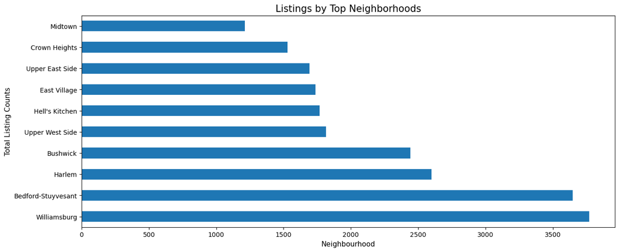

```python
Top_10_Neighbourhoods= df['neighbourhood'].value_counts().nlargest(10)
Top_10_Neighbourhoods.plot(kind='barh', figsize=(15, 6))

plt.xlabel('Neighbourhood', fontsize=11)
plt.ylabel('Total Listing Counts', fontsize=11)
plt.title('Listings by Top Neighborhoods', fontsize=15)
```